# Script R pour le traitement des données de l’expérience 1

Jérémy Béna

12 août 2017

Ce document vise à montrer le script conçu pour traiter les données. Des données générées aléatoirement sont utilisées pour l’exemplifier.

# Initialisation et visualisation

Dans un premier temps, on récupère les données qui ont été stockées dans un fichier .csv. On les associe ensuite à un data frame.

```r
data = read.csv("C:/Users/benaj/Dropbox/Dossier EXP/Expérience 1/exp/traitements/csv/data/data_exp1.csv")

data_extend = read.csv("C:/Users/benaj/Dropbox/Dossier EXP/Expérience 1/exp/traitements/csv/data/data_extendexp1.csv")

#Chemin du fichier sur mon ordinateur
```

On fait des VI inter-groupe des facteurs afin de pouvoir les utiliser ensuite. Les ANOVA supposent de traiter les participants comme un facteur.

```r
data$manip_attention = as.factor(data$manip_attention)
data$manip_cred = as.factor(data$manip_cred)
data$ppt = as.factor(data$ppt)

data_extend$manip_attention = as.factor(data_extend$manip_attention)
data_extend$manip_cred = as.factor(data_extend$manip_cred)
data_extend$ppt = as.factor(data_extend$ppt)
```

On peut jeter un oeil aux données, sous forme de tableaux

```r
head(data)
```

```
  X ppt age       sex                    situation manip_attention
1 1   1  25 Une Femme                   Etudiant-e              nd
2 2   2  24  Un Homme                  Sans emploi              nd
3 3   3  24  Un Homme                   Etudiant-e              nd
4 4   4  47 Une Femme                  Sans emploi               d
5 5   5  19 Une Femme En activitÃ© professionnelle               d
6 6   6  25 Une Femme                   Etudiant-e              nd
  manip_cred                                   cred_list1
1          c  Tous les Ã©noncÃ©s de cette liste sont FAUX
2         nc                                         <NA>
3          c Tous les Ã©noncÃ©s de cette liste sont VRAIS
4          c  Tous les Ã©noncÃ©s de cette liste sont FAUX
5         nc                                         <NA>
6          c  Tous les Ã©noncÃ©s de cette liste sont FAUX
                                    cred_list2
```

[output cut: 76 more lines]

```r
summary(data)
```

```
       X               ppt          age              sex
 Min.   :  1.00   1      : 1   Min.   :19.0   Un Homme :40
 1st Qu.: 25.75   2      : 1   1st Qu.:24.0   Une Femme:60
 Median : 50.50   3      : 1   Median :24.0
 Mean   : 50.50   4      : 1   Mean   :27.8
 3rd Qu.: 75.25   5      : 1   3rd Qu.:25.0
 Max.   :100.00   6      : 1   Max.   :47.0
                  (Other):94
                        situation  manip_attention manip_cred
 En activitÃ© professionnelle:20   d :40           c :60
 Etudiant-e                  :40   nd:60           nc:40
 Sans emploi                 :40




                                        cred_list1
 Tous les Ã©noncÃ©s de cette liste sont FAUX :40
 Tous les Ã©noncÃ©s de cette liste sont VRAIS:20
 NA's                                        :40




                                        cred_list2
 Tous les Ã©noncÃ©s de cette liste sont FAUX :20
 Tous les Ã©noncÃ©s de cette liste sont VRAIS:40
 NA's                                        :40




                                                     idee_exp
 Blabla                                                  :20
 Bliblabla                                               :20
 Bloublabli                                              :20
 tester ma mÃ©moire et mes mathematiques et mon attention:20
 NA's                                                    :20


```

[output cut: 64 more lines]

```
   prop_l2_l1     prop_cred_nocred prop_nocred_cred prop_l1_other
 Min.   :0.1429   Min.   :0.1429   Min.   :0.2857   Min.   :0.5000
 1st Qu.:0.2143   1st Qu.:0.2143   1st Qu.:0.2857   1st Qu.:0.5714
 Median :0.3571   Median :0.2143   Median :0.3571   Median :0.5714
 Mean   :0.3493   Mean   :0.3021   Mean   :0.3779   Mean   :0.5929
 3rd Qu.:0.5000   3rd Qu.:0.5000   3rd Qu.:0.5000   3rd Qu.:0.6429
 Max.   :0.5000   Max.   :0.5000   Max.   :0.5000   Max.   :0.6429

 prop_l2_other    prop_cred_other  prop_nocred_other
 Min.   :0.3571   Min.   :0.3571   Min.   :0.5000
 1st Qu.:0.3571   1st Qu.:0.3571   1st Qu.:0.5000
 Median :0.5000   Median :0.5714   Median :0.5714
 Mean   :0.5050   Mean   :0.5250   Mean   :0.5729
 3rd Qu.:0.6429   3rd Qu.:0.6429   3rd Qu.:0.6429
 Max.   :0.6429   Max.   :0.6429   Max.   :0.6429
```

```r
head(data_extend)
```

```
  X
1 1
2 2
3 3
4 4
5 5
6 6
                                                                              enonce
1                                      Bramante est un architecte de la Renaissance.
2       Brecht a Ã©crit la piÃ¨ce 'La vie de GalilÃ©e' pendant son exil au Danemark.
3    Charlemagne a Ã©tÃ© couronnÃ© Empereur d'Occident par le Pape le jour de NoÃ«l.
4        Dans le conte de fÃ©es 'Les Souliers usÃ©s Ã  la danse', le roi a 7 filles.
5 Dans les annÃ©es 1930, la tÃ©lÃ©vision Ã©tait appelÃ©e 'cinÃ©ma avec son distant'.
6                         En France, la tÃ©lÃ©phonie automatique a dÃ©butÃ© en 1907.
  ppt age       sex  situation manip_attention manip_cred
```

[output cut: 41 more lines]

```r
summary(data_extend)
```

```
       X
 Min.   :   1
 1st Qu.:1121
 Median :2240
 Mean   :2240
 3rd Qu.:3360
 Max.   :4480

                                                                                      enonce
 Georg Philipp Telemann est nÃ© Ã  Leipzig.                                              :  80
 L'alphabet HawaÃ¯en contient plus de lettres que l'alphabet Allemand.                   :  80
 La cravate est issue du col des mercenaires croates.                                    :  80
 Le cholÃ©calcifÃ©rol est une vitamine trouvÃ©e dans les fruits.                         :  80
 Le cobalt est un Ã©lÃ©ment chimique utilisÃ© dans la fabrication des siÃ¨ges de voiture.:  80
 Le cothurne Ã©tait une ceinture romaine.                                                :  80
 (Other)                                                                                 :4000
      ppt            age              sex
 77     : 112   Min.   :19.0   Un Homme :1792
 1      :  56   1st Qu.:24.0   Une Femme:2688
 2      :  56   Median :24.0
 3      :  56   Mean   :27.8
 4      :  56   3rd Qu.:25.0
 5      :  56   Max.   :47.0
 (Other):4088
                        situation    manip_attention manip_cred
 En activitÃ© professionnelle: 896   d :1792         c :2744
 Etudiant-e                  :1792   nd:2688         nc:1736
 Sans emploi                 :1792




                                        cred_list1
 Tous les Ã©noncÃ©s de cette liste sont FAUX :1792
 Tous les Ã©noncÃ©s de cette liste sont VRAIS: 896
 NA's                                        :1792




```

[output cut: 25 more lines]

```
 Min.   :    3.00   Min.   :0.0000   Min.   :1.00
 1st Qu.:   84.25   1st Qu.:0.0000   1st Qu.:1.75
 Median :  248.00   Median :1.0000   Median :2.50
 Mean   :  789.08   Mean   :0.5643   Mean   :2.25
 3rd Qu.:  407.00   3rd Qu.:1.0000   3rd Qu.:3.00
 Max.   :14030.00   Max.   :1.0000   Max.   :3.00

       enonce_credsource source_rating    source_time    source_correct
 cred l1        : 224    Min.   :1.000   Min.   :    0   Min.   :0.000
 cred l2        : 448    1st Qu.:1.000   1st Qu.:  109   1st Qu.:0.000
 no cred l1     : 448    Median :2.000   Median :  336   Median :0.000
 no cred l2     : 224    Mean   :1.957   Mean   :  760   Mean   :0.425
 no manip list 1: 448    3rd Qu.:3.000   3rd Qu.:  989   3rd Qu.:1.000
 no manip list 2: 448    Max.   :3.000   Max.   :11278   Max.   :1.000
 nouveaux       :2240
```

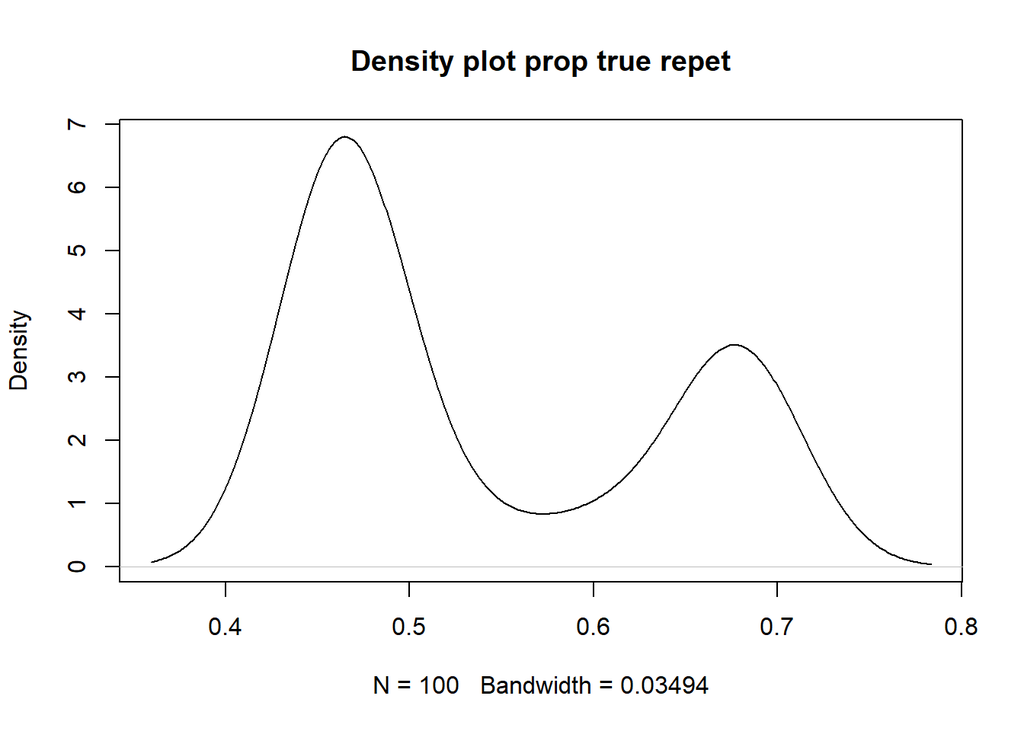

```r
plot(density(data$prop_true_r),main="Density plot prop true repet")
```

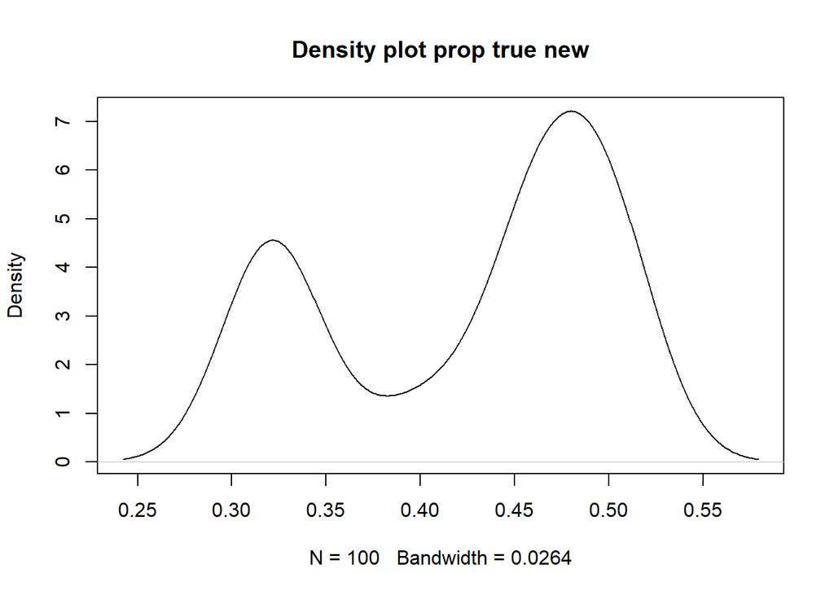

```r
plot(density(data$prop_true_n),main="Density plot prop true new")
```

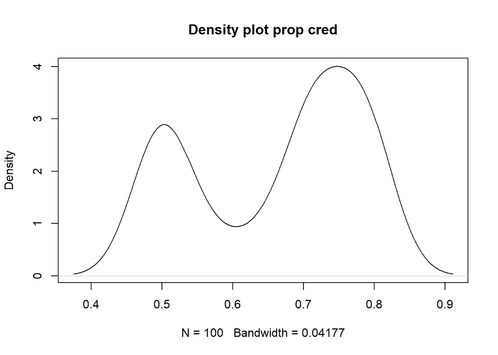

```r
plot(density(data$prop_true_cred),main="Density plot prop cred")
```

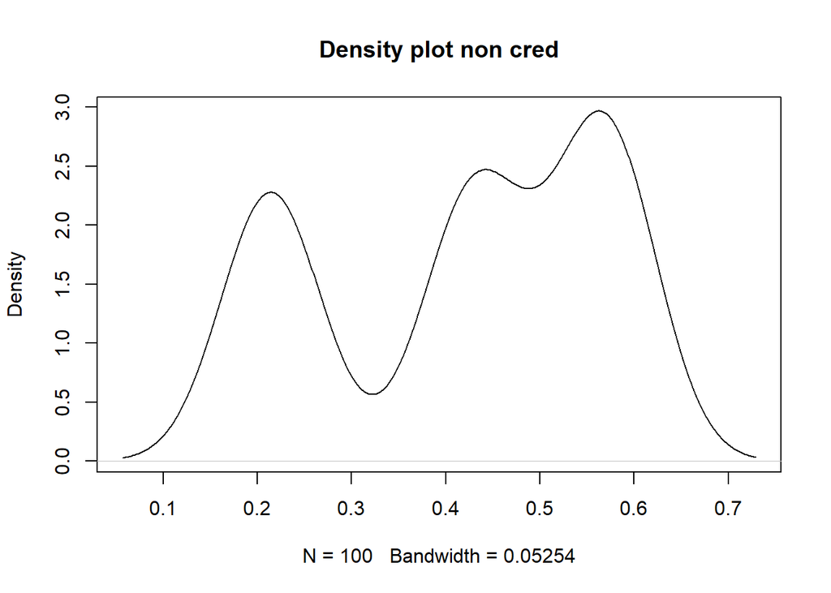

```r
plot(density(data$prop_true_noncred),main="Density plot non cred")
```

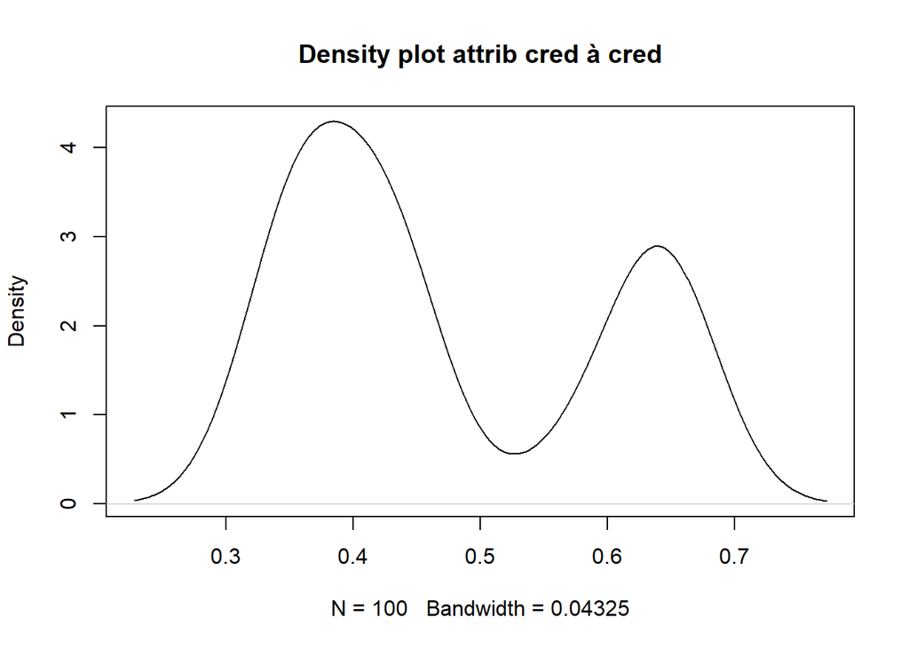

```r
plot(density(data$prop_cred_cred),main="Density plot attrib cred à cred")
```

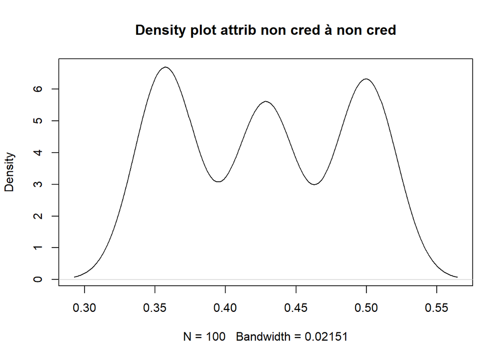

```r
plot(density(data$prop_nocred_nocred),main="Density plot attrib non cred à non cred")
```

Des graphiques plus précis sur la distribution des données en fonction des deux facteurs inter groupes peuvent être visualisés. (les titres sont trop longs et risquent d’être mal représentés)

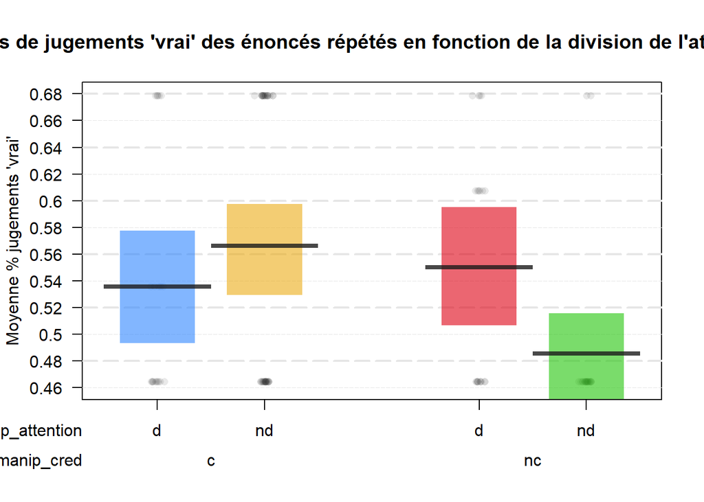

```r
require(yarrr) #Graphiques avec le package "yarrr"
#Proportion jugements vrais énoncés répétés
pirateplot(prop_true_r~manip_attention+manip_cred,data=data,
           pal = gray(.1), #spécifie la couleur de la barre montrant la moyenne
           avg.line.o = .8, #Transparence de la barre représentation la moyenne
           theme = 0, #On peut spécifier le thème au besoin
           inf.f.o = .6, #Là on a le niveau de transparence de l'intervalle de confiance
           inf.f.col = piratepal("southpark"), #On peut choisir la couleur à associer.
           point.o = .1, #Modifier la transparence des points qui représentent les observations
           gl.col = gray(.9), #On peut spécifier la transparence des lignes horizontales
           gl.lty = 5, #Leur aspect également (continu, pointillé...)
           gl.lwd = c(.3, 2), #leur épaisseur, là une ligne sur deux.
           main = "Moyennes proportions de jugements 'vrai' des énoncés répétés en fonction de la division de l'attention et de la crédibilité", #ajouter un titre en haut
           xlab = "Manipulation de l'attention", #Changer le nom de l'axe VI
           ylab = "Moyenne % jugements 'vrai'") #Changer le nom de l'axe VD
```

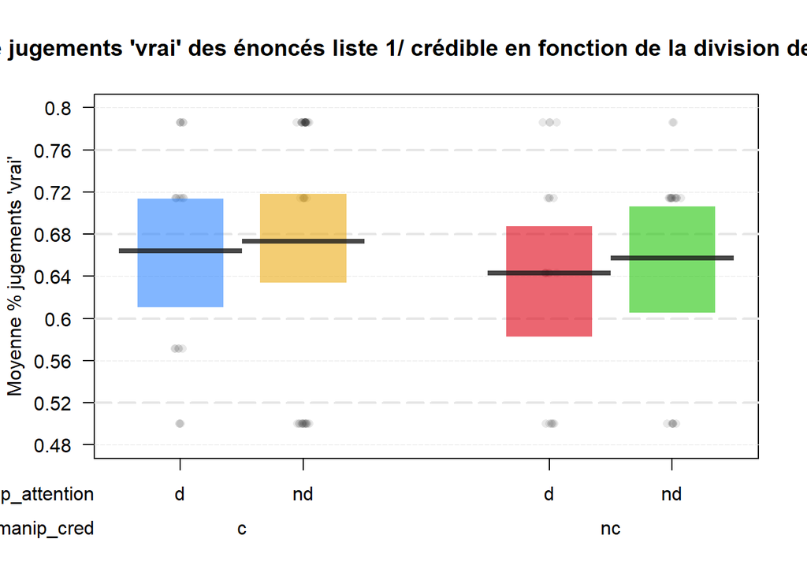

```r
#Proportion jugements vrais énoncés liste 1/ crédibles
pirateplot(prop_true_cred~manip_attention+manip_cred,data=data,
           pal = gray(.1), #spécifie la couleur de la barre montrant la moyenne
           avg.line.o = .8, #Transparence de la barre représentation la moyenne
           theme = 0, #On peut spécifier le thème au besoin
           inf.f.o = .6, #Là on a le niveau de transparence de l'intervalle de confiance
           inf.f.col = piratepal("southpark"), #On peut choisir la couleur à associer.
           point.o = .1, #Modifier la transparence des points qui représentent les observations
           gl.col = gray(.9), #On peut spécifier la transparence des lignes horizontales
           gl.lty = 5, #Leur aspect également (continu, pointillé...)
           gl.lwd = c(.3, 2), #leur épaisseur, là une ligne sur deux.
           main = "Moyennes proportions de jugements 'vrai' des énoncés liste 1/ crédible en fonction de la division de l'attention et de la crédibilité", #ajouter un titre en haut
           xlab = "Manipulation de l'attention", #Changer le nom de l'axe VI
           ylab = "Moyenne % jugements 'vrai'") #Changer le nom de l'axe VD
```

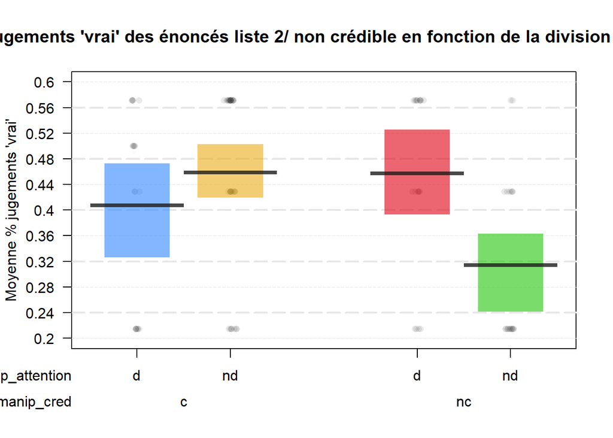

```r
#Proportion jugements vrais énoncés liste 2/ non crédibles
pirateplot(prop_true_noncred~manip_attention+manip_cred,data=data,
           pal = gray(.1), #spécifie la couleur de la barre montrant la moyenne
           avg.line.o = .8, #Transparence de la barre représentation la moyenne
           theme = 0, #On peut spécifier le thème au besoin
           inf.f.o = .6, #Là on a le niveau de transparence de l'intervalle de confiance
           inf.f.col = piratepal("southpark"), #On peut choisir la couleur à associer.
           point.o = .1, #Modifier la transparence des points qui représentent les observations
           gl.col = gray(.9), #On peut spécifier la transparence des lignes horizontales
           gl.lty = 5, #Leur aspect également (continu, pointillé...)
           gl.lwd = c(.3, 2), #leur épaisseur, là une ligne sur deux.
           main = "Moyennes proportions de jugements 'vrai' des énoncés liste 2/ non crédible en fonction de la division de l'attention et de la crédibilité", #ajouter un titre en haut
           xlab = "Manipulation de l'attention", #Changer le nom de l'axe VI
           ylab = "Moyenne % jugements 'vrai'") #Changer le nom de l'axe VD
```

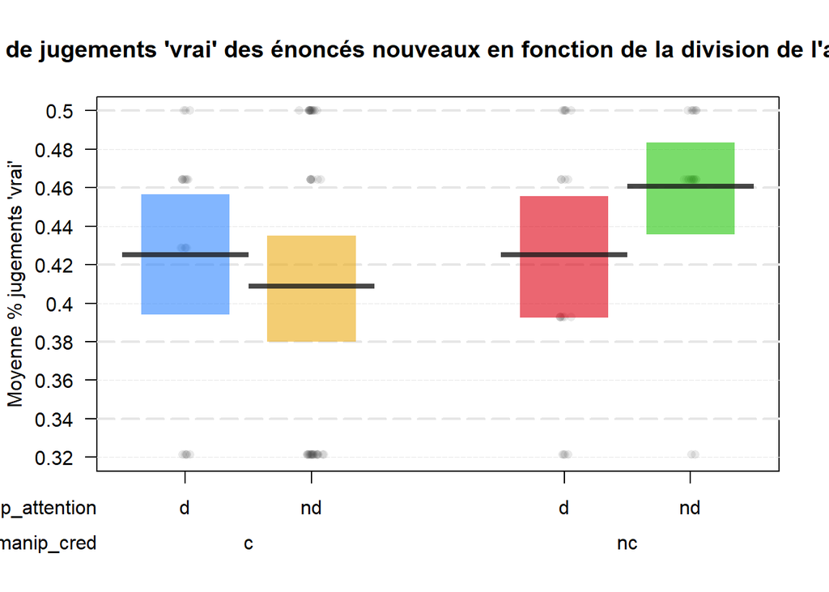

```r
#Proportion jugements vrais énoncés nouveaux
pirateplot(prop_true_n~manip_attention+manip_cred,data=data,
           pal = gray(.1), #spécifie la couleur de la barre montrant la moyenne
           avg.line.o = .8, #Transparence de la barre représentation la moyenne
           theme = 0, #On peut spécifier le thème au besoin
           inf.f.o = .6, #Là on a le niveau de transparence de l'intervalle de confiance
           inf.f.col = piratepal("southpark"), #On peut choisir la couleur à associer.
           point.o = .1, #Modifier la transparence des points qui représentent les observations
           gl.col = gray(.9), #On peut spécifier la transparence des lignes horizontales
           gl.lty = 5, #Leur aspect également (continu, pointillé...)
           gl.lwd = c(.3, 2), #leur épaisseur, là une ligne sur deux.
           main = "Moyennes proportions de jugements 'vrai' des énoncés nouveaux en fonction de la division de l'attention et de la crédibilité", #ajouter un titre en haut
           xlab = "Manipulation de l'attention", #Changer le nom de l'axe VI
           ylab = "Moyenne % jugements 'vrai'") #Changer le nom de l'axe VD
```

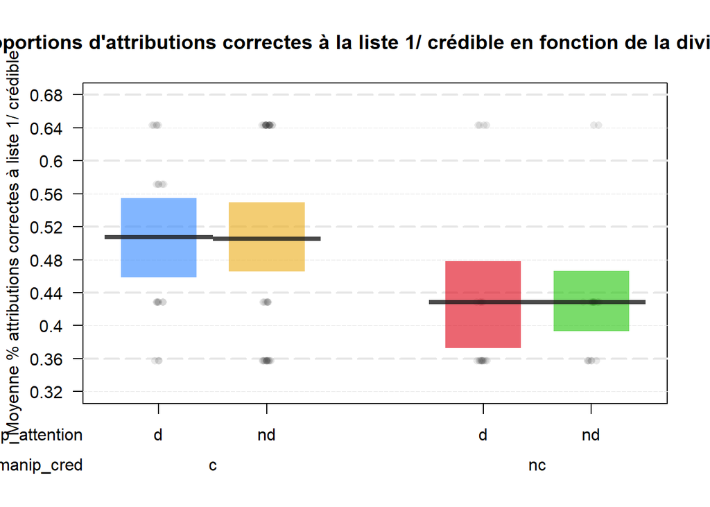

```r
#Proportion d'attributions correctes à la liste1/ crédible
pirateplot(prop_cred_cred~manip_attention+manip_cred,data=data,
           pal = gray(.1), #spécifie la couleur de la barre montrant la moyenne
           avg.line.o = .8, #Transparence de la barre représentation la moyenne
           theme = 0, #On peut spécifier le thème au besoin
           inf.f.o = .6, #Là on a le niveau de transparence de l'intervalle de confiance
           inf.f.col = piratepal("southpark"), #On peut choisir la couleur à associer.
           point.o = .1, #Modifier la transparence des points qui représentent les observations
           gl.col = gray(.9), #On peut spécifier la transparence des lignes horizontales
           gl.lty = 5, #Leur aspect également (continu, pointillé...)
           gl.lwd = c(.3, 2), #leur épaisseur, là une ligne sur deux.
           main = "Moyennes proportions d'attributions correctes à la liste 1/ crédible en fonction de la division de l'attention", #ajouter un titre en haut
           xlab = "Manipulation de l'attention", #Changer le nom de l'axe VI
           ylab = "Moyenne % attributions correctes à liste 1/ crédible") #Changer le nom de l'axe VD
```

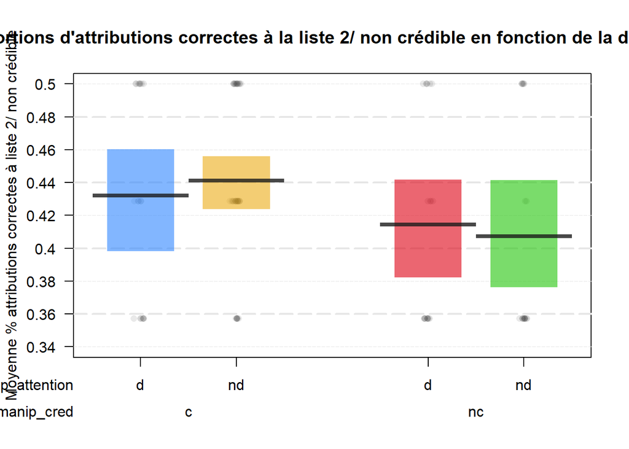

```r
#Proportion d'attributions correctes à la liste2/ non crédible

pirateplot(prop_nocred_nocred~manip_attention+manip_cred,data=data,
           pal = gray(.1), #spécifie la couleur de la barre montrant la moyenne
           avg.line.o = .8, #Transparence de la barre représentation la moyenne
           theme = 0, #On peut spécifier le thème au besoin
           inf.f.o = .6, #Là on a le niveau de transparence de l'intervalle de confiance
           inf.f.col = piratepal("southpark"), #On peut choisir la couleur à associer.
           point.o = .1, #Modifier la transparence des points qui représentent les observations
           gl.col = gray(.9), #On peut spécifier la transparence des lignes horizontales
           gl.lty = 5, #Leur aspect également (continu, pointillé...)
           gl.lwd = c(.3, 2), #leur épaisseur, là une ligne sur deux.
           main = "Moyennes proportions d'attributions correctes à la liste 2/ non crédible en fonction de la division de l'attention", #ajouter un titre en haut
           xlab = "Manipulation de l'attention", #Changer le nom de l'axe VI
           ylab = "Moyenne % attributions correctes à liste 2/ non crédible") #Changer le nom de l'axe VD
```

# Test de la normalité

Vérifions la normalité des données :

```r
shapiro.test(data$prop_true_r)
```

```
    Shapiro-Wilk normality test

data:  data$prop_true_r
W = 0.66818, p-value = 1.039e-13
```

```r
shapiro.test(data$prop_true_cred)
```

```
    Shapiro-Wilk normality test

data:  data$prop_true_cred
W = 0.789, p-value = 1.154e-10
```

```r
shapiro.test(data$prop_true_noncred)
```

```
    Shapiro-Wilk normality test

data:  data$prop_true_noncred
W = 0.78122, p-value = 6.826e-11
```

```r
shapiro.test(data$prop_true_n)
```

```
    Shapiro-Wilk normality test

data:  data$prop_true_n
W = 0.7691, p-value = 3.09e-11
```

```r
shapiro.test(data$prop_cred_cred)
```

```
    Shapiro-Wilk normality test

data:  data$prop_cred_cred
W = 0.75243, p-value = 1.086e-11
```

```r
shapiro.test(data$prop_nocred_nocred)
```

```
    Shapiro-Wilk normality test

data:  data$prop_nocred_nocred
W = 0.78354, p-value = 7.972e-11
```

Les données ne suivent pas une loi normale dans cet exemple.

# ANOVAs

Chargement des packages nécessaires aux traitements et graphiques à faire

```r
require(ggplot2)
require(gplots) #Graphiques
require(psych) #Stats descriptives et analyses
require(lme4) #Analyses
require(ez) #Analyses
require(compute.es) #Tailles d'effets
require(dplyr) #pour la fonction gather()
require(tidyr)
require(xtable)#tableaux LaTeX
```

Afin de faire les ANOVA mixtes, il faut opérer des changements dans les données. La variable intra doit être explicitée

Bien qu’elle ne soit pas directement utile, j’ai créé un data frame distinguant les énoncés répétés et les nouveaux pour voir les variations du jugement de vérité

```r
data_rep <- gather(data, repetition, value, prop_true_r:prop_true_n)
data_rep$ppt <- as.factor(data_rep$ppt)
```

Idem pour la distinction entre liste 1/ crédible ; liste 2/ non crédible ; nouveaux pour les variations du jugement de vérité

```r
#Créer trois entrées pour chaque participant (une list1/ cred ; liste 1/ no cred ; une nouv)
data_source <- gather(data, source, value, prop_true_cred,prop_true_noncred,prop_true_n)
data_source$ppt <- as.factor(data_source$ppt)
```

Même chose pour les attributions, avec la distinction entre liste 1/ crédible et liste 2/ non crédible

```r
data_attrib <- gather(data, attrib, value, prop_cred_cred,prop_nocred_nocred)
data_attrib$ppt <- as.factor(data_attrib$ppt)
```

On peut maintenant réaliser les ANOVA.

Anova 2x2x3 sur la proportion de jugements ‘vrai’

```r
aov_source_att_credez = ezANOVA(data = data_source #Data frame source
        , dv = value #La VD est appelée value
        , wid = ppt #On indique que c'est une variable intra
        , within = source #On la spécifie ici
        , between = .(manip_attention,manip_cred) #On ajoute les VI inter
        , return_aov = TRUE

)
```

On étudie les sorties du modèle

```r
aov_source_att_credez
```

```
$ANOVA
                             Effect DFn DFd           F            p p<.05
2                   manip_attention   1  96   0.3397478 5.613415e-01
3                        manip_cred   1  96   4.1619111 4.408950e-02     *
5                            source   2 192 114.9254956 1.519312e-33     *
4        manip_attention:manip_cred   1  96   7.7080293 6.610211e-03     *
6            manip_attention:source   2 192   0.7672905 4.656875e-01
7                 manip_cred:source   2 192   2.8898523 5.800594e-02
8 manip_attention:manip_cred:source   2 192   5.8793212 3.324898e-03     *
           ges
2 0.0004348856
3 0.0053014115
5 0.5121877733
4 0.0097742800
6 0.0069612332
7 0.0257228051
8 0.0509758628

$`Mauchly's Test for Sphericity`
                             Effect         W         p p<.05
5                            source 0.9849024 0.4854864
6            manip_attention:source 0.9849024 0.4854864
7                 manip_cred:source 0.9849024 0.4854864
8 manip_attention:manip_cred:source 0.9849024 0.4854864

$`Sphericity Corrections`
                             Effect      GGe        p[GG] p[GG]<.05
5                            source 0.985127 4.369126e-33         *
6            manip_attention:source 0.985127 4.639285e-01
7                 manip_cred:source 0.985127 5.884424e-02
8 manip_attention:manip_cred:source 0.985127 3.490396e-03         *
       HFe        p[HF] p[HF]<.05
5 1.005611 1.519312e-33         *
6 1.005611 4.656875e-01
7 1.005611 5.800594e-02
8 1.005611 3.324898e-03         *

$aov

Call:
```

[output cut: 15 more lines]

[output not shown]

Les post-hoc avec correction de Tukey étant délicats à réaliser ici, je pense les faire avec le logiciel JAMOVI.

On réalise la deuxième Anova

```r
aov_attrib_att_credez = ezANOVA(data = data_attrib
                                , dv = value
                                , wid = ppt
                                , within = attrib
                                , between = .(manip_attention,manip_cred)
                                , return_aov = TRUE
)
```

On étudie les sorties du modèle

```r
aov_attrib_att_credez
```

[output not shown]

# Graphiques et tableaux

Représenter graphiquement les données, et avoir les tableaux qui sous-tendent ces graphiques peut être utile pour interpréter les résultats et les communiquer. Compte tenu de la nature des VD (%) et des VI (intra et inter), des boxplot représentant les moyennes et intervalles de confiance à 95% sont informatifs.

Tout d’abord, sur le jugement de vérité

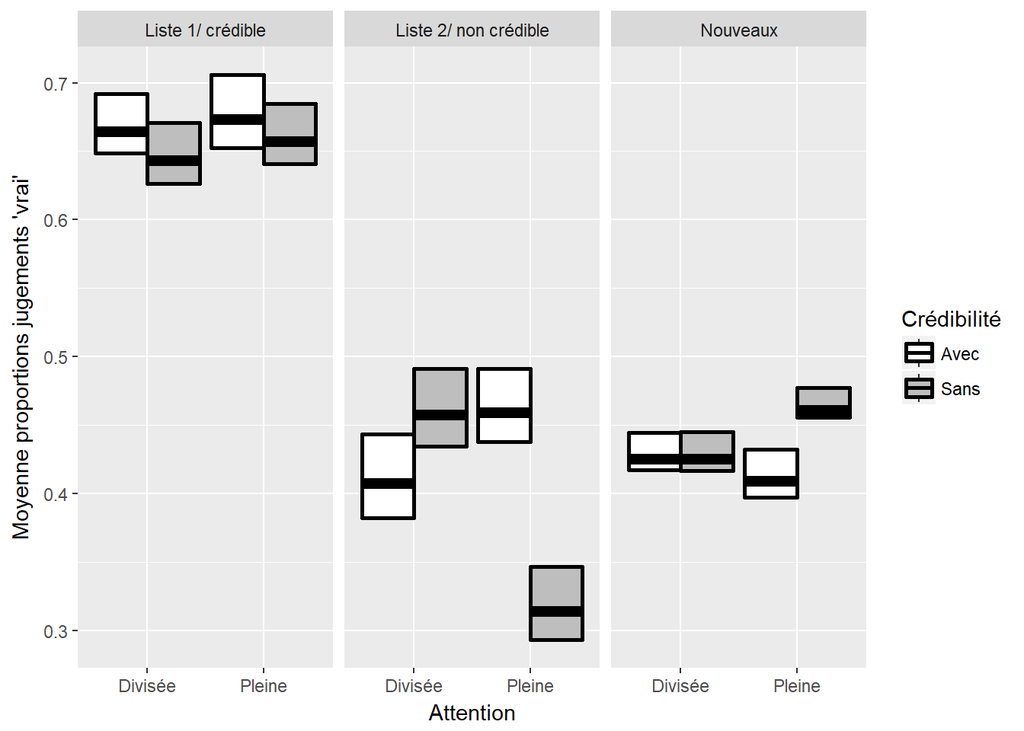

```r
plot <- data_source %>% group_by(source, manip_attention, manip_cred) %>%
  summarize(Proportion = mean(value), SE = (sd(value)/(sqrt(100))))
plot$source = factor(plot$source, levels = c("prop_true_cred","prop_true_noncred","prop_true_n"),
                    labels = c("Liste 1/ crédible", "Liste 2/ non crédible", "Nouveaux"))
plot$manip_attention = factor(plot$manip_attention, levels = c("d","nd"),
                          labels = c("Divisée","Pleine"))
plot$manip_cred = factor(plot$manip_cred, levels = c("c","nc"),
                            labels = c("Avec","Sans"))

a <- ggplot(plot, aes(x = manip_attention, y = Proportion, fill = manip_cred)) +
  geom_boxplot() +
  geom_crossbar(aes(ymin = Proportion-1.96*SE+.5/100, ymax=Proportion+1.96*SE+.5/75),
                position=position_dodge(.9), size=1, color = "black")+
  facet_wrap(~ source)+labs(x = "Attention", y = "Moyenne proportions jugements 'vrai'", fill = "Crédibilité")+
scale_fill_manual("Crédibilité", values = c("Avec" = "white", "Sans" = "grey"))


a
```

On peut enregistrer l’image au besoin

```r
pdf("C:\\Users\\benaj\\Dropbox\\Dossier EXP\\Expérience 1\\exp\\traitements\\judg.pdf",height=6, width=6)
plot(a)
dev.off()
```

Un tableau avec commandes LaTeX peut facilement être obtenu

```r
tab_plot = xtable(plot)
tab_plot
```

```
% latex table generated in R 3.4.1 by xtable 1.8-2 package
% Thu Sep 07 18:11:05 2017
\begin{table}[ht]
\centering
\begin{tabular}{rlllrr}
  \hline
 & source & manip\_attention & manip\_cred & Proportion & SE \\
  \hline
1 & Liste 1/ crédible & Divisée & Avec & 0.66 & 0.01 \\
  2 & Liste 1/ crédible & Divisée & Sans & 0.64 & 0.01 \\
  3 & Liste 1/ crédible & Pleine & Avec & 0.67 & 0.01 \\
  4 & Liste 1/ crédible & Pleine & Sans & 0.66 & 0.01 \\
  5 & Nouveaux & Divisée & Avec & 0.42 & 0.01 \\
  6 & Nouveaux & Divisée & Sans & 0.42 & 0.01 \\
  7 & Nouveaux & Pleine & Avec & 0.41 & 0.01 \\
  8 & Nouveaux & Pleine & Sans & 0.46 & 0.01 \\
  9 & Liste 2/ non crédible & Divisée & Avec & 0.41 & 0.02 \\
  10 & Liste 2/ non crédible & Divisée & Sans & 0.46 & 0.01 \\
  11 & Liste 2/ non crédible & Pleine & Avec & 0.46 & 0.01 \\
  12 & Liste 2/ non crédible & Pleine & Sans & 0.31 & 0.01 \\
   \hline
\end{tabular}
\end{table}
```

On fait la même chose avec les attributions

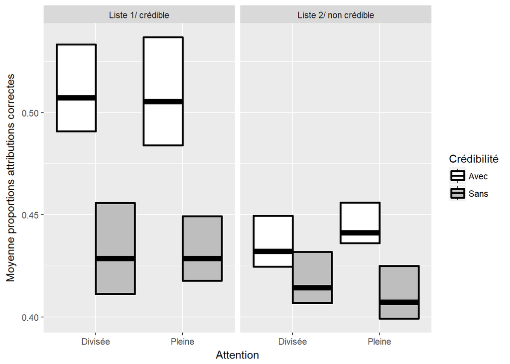

```r
plot2 <- data_attrib %>% group_by(attrib, manip_attention, manip_cred) %>%
  summarize(Proportion = mean(value), SE = (sd(value)/(sqrt(100))))
plot2$attrib = factor(plot2$attrib, levels = c("prop_cred_cred","prop_nocred_nocred"),
                     labels = c("Liste 1/ crédible", "Liste 2/ non crédible"))
plot2$manip_attention = factor(plot2$manip_attention, levels = c("d","nd"),
                              labels = c("Divisée","Pleine"))
plot2$manip_cred = factor(plot2$manip_cred, levels = c("c","nc"),
                         labels = c("Avec","Sans"))

b <- ggplot(plot2, aes(x = manip_attention, y = Proportion, fill = manip_cred)) +
  geom_boxplot() +
  geom_crossbar(aes(ymin = Proportion-1.96*SE+.5/100, ymax=Proportion+1.96*SE+.5/100),
                position=position_dodge(.9), size=1, color = "black")+
  facet_wrap(~ attrib)+labs(x = "Attention", y = "Moyenne proportions attributions correctes", fill = "Crédibilité")+
  scale_fill_manual("Crédibilité", values = c("Avec" = "white", "Sans" = "grey"))

b
```

Enregistrement de l’image

```r
pdf("C:\\Users\\benaj\\Dropbox\\Dossier EXP\\Expérience 1\\exp\\traitements\\attrib.pdf",height=6, width=6)
plot(b)
dev.off()
```

Tableau

```r
tab_plot2 = xtable(plot2)
tab_plot2
```

```
% latex table generated in R 3.4.1 by xtable 1.8-2 package
% Thu Sep 07 18:11:07 2017
\begin{table}[ht]
\centering
\begin{tabular}{rlllrr}
  \hline
 & attrib & manip\_attention & manip\_cred & Proportion & SE \\
  \hline
1 & Liste 1/ crédible & Divisée & Avec & 0.51 & 0.01 \\
  2 & Liste 1/ crédible & Divisée & Sans & 0.43 & 0.01 \\
  3 & Liste 1/ crédible & Pleine & Avec & 0.51 & 0.01 \\
  4 & Liste 1/ crédible & Pleine & Sans & 0.43 & 0.01 \\
  5 & Liste 2/ non crédible & Divisée & Avec & 0.43 & 0.01 \\
  6 & Liste 2/ non crédible & Divisée & Sans & 0.41 & 0.01 \\
  7 & Liste 2/ non crédible & Pleine & Avec & 0.44 & 0.01 \\
  8 & Liste 2/ non crédible & Pleine & Sans & 0.41 & 0.01 \\
   \hline
\end{tabular}
\end{table}
```

# Analyses supplémentaires

En plus de ces analyses, d’autres peuvent être réalisées. On peut par exemple étudier uniquement l’effet de vérité avec un t test ; et utiliser des modèles linéaires généralisés pour tester les principales hypothèses (1) avec des régressions logistiques et (2) en spécifiant des variables aléatoires.

```r
ttest = t.test(data$prop_true_r,data$prop_true_n,paired=TRUE)
pirateplot(value~repetition,data=data_rep,plot=FALSE)
```

```
$summary
   repetition bean.num   n       avg    inf.lb    inf.ub
1 prop_true_n        1 100 0.4257143 0.4106054 0.4390106
2 prop_true_r        2 100 0.5407143 0.5221033 0.5601876

$avg.line.fun
[1] "mean"

$inf.method
[1] "hdi"

$inf.p
[1] 0.95
```

Pour du logistique avec variables aléatoires avec jugement de vérité et jugement de source en fonction des principales VI :

```r
model_t_log <- glmer(truth_rating_num ~ enonce_repetition*manip_attention*manip_cred+(1|ppt)+(1|enonce),family=binomial,data=data_extend)
summary(model_t_log)
```

```
Generalized linear mixed model fit by maximum likelihood (Laplace
  Approximation) [glmerMod]
 Family: binomial  ( logit )
Formula:
truth_rating_num ~ enonce_repetition * manip_attention * manip_cred +
    (1 | ppt) + (1 | enonce)
   Data: data_extend

     AIC      BIC   logLik deviance df.resid
  3969.2   4033.3  -1974.6   3949.2     4470

Scaled residuals:
    Min      1Q  Median      3Q     Max
-3.5266 -0.5588 -0.0295  0.5734  2.6065

Random effects:
 Groups Name        Variance  Std.Dev.
 enonce (Intercept) 2.282e+01 4.777209
 ppt    (Intercept) 6.066e-06 0.002463
Number of obs: 4480, groups:  enonce, 99; ppt, 79

Fixed effects:
                                                  Estimate Std. Error
(Intercept)                                        -1.7602     0.5188
enonce_repetitionr                                  2.7953     0.2381
manip_attentionnd                                   0.1896     0.1527
manip_crednc                                       -0.2622     0.1753
enonce_repetitionr:manip_attentionnd               -0.2562     0.2090
enonce_repetitionr:manip_crednc                     0.7030     0.2385
manip_attentionnd:manip_crednc                      0.4894     0.2681
enonce_repetitionr:manip_attentionnd:manip_crednc  -2.5792     0.3968
                                                  z value Pr(>|z|)
(Intercept)                                        -3.393 0.000693 ***
enonce_repetitionr                                 11.738  < 2e-16 ***
manip_attentionnd                                   1.241 0.214488
manip_crednc                                       -1.496 0.134635
enonce_repetitionr:manip_attentionnd               -1.226 0.220290
enonce_repetitionr:manip_crednc                     2.948 0.003203 **
manip_attentionnd:manip_crednc                      1.825 0.067948 .
enonce_repetitionr:manip_attentionnd:manip_crednc  -6.499 8.06e-11 ***
---
Signif. codes:  0 '***' 0.001 '**' 0.01 '*' 0.05 '.' 0.1 ' ' 1

Correlation of Fixed Effects:
                  (Intr) ennc_r mnp_tt mnp_cr ennc_rpttnr:mnp_t
ennc_rpttnr       -0.238
mnp_ttntnnd       -0.194  0.437
manip_crdnc       -0.142  0.307  0.495
ennc_rpttnr:mnp_t  0.141 -0.572 -0.736 -0.362
ennc_rpttnr:mnp_c  0.102 -0.407 -0.363 -0.735  0.488
mnp_ttntn:_        0.046 -0.078 -0.528 -0.664  0.387
ennc_rp:_:_        0.003 -0.019  0.334  0.452 -0.475
                  ennc_rpttnr:mnp_c mnp_:_
ennc_rpttnr
mnp_ttntnnd
manip_crdnc
ennc_rpttnr:mnp_t
ennc_rpttnr:mnp_c
mnp_ttntn:_        0.491
ennc_rp:_:_       -0.620            -0.733
convergence code: 0
Model failed to converge with max|grad| = 0.0802762 (tol = 0.001, component 1)
```

```r
anova(model_t_log)
```

```
Analysis of Variance Table
                                             Df  Sum Sq Mean Sq  F value
enonce_repetition                             1 147.785 147.785 147.7852
manip_attention                               1   3.379   3.379   3.3789
manip_cred                                    1   5.115   5.115   5.1149
enonce_repetition:manip_attention             1  19.738  19.738  19.7379
enonce_repetition:manip_cred                  1   0.916   0.916   0.9157
manip_attention:manip_cred                    1  18.368  18.368  18.3683
enonce_repetition:manip_attention:manip_cred  1  41.605  41.605  41.6046
```

```r
model_att_log <- glmer(source_correct ~ enonce_repetition*manip_attention*manip_cred+(1|ppt)+(1|enonce),family=binomial,data=data_extend)
summary(model_att_log)
```

```
Generalized linear mixed model fit by maximum likelihood (Laplace
  Approximation) [glmerMod]
 Family: binomial  ( logit )
Formula:
source_correct ~ enonce_repetition * manip_attention * manip_cred +
    (1 | ppt) + (1 | enonce)
   Data: data_extend

     AIC      BIC   logLik deviance df.resid
  4200.1   4264.2  -2090.1   4180.1     4470

Scaled residuals:
     Min       1Q   Median       3Q      Max
-1.78730 -0.60259 -0.07459  0.57066  2.76317

Random effects:
 Groups Name        Variance Std.Dev.
 enonce (Intercept) 18.3234  4.2806
 ppt    (Intercept)  0.2385  0.4883
Number of obs: 4480, groups:  enonce, 99; ppt, 79

Fixed effects:
                                                  Estimate Std. Error
(Intercept)                                        -0.6296     0.4793
enonce_repetitionr                                  0.2770     0.2065
manip_attentionnd                                   0.5714     0.2013
manip_crednc                                       -0.4747     0.2391
enonce_repetitionr:manip_attentionnd               -0.3115     0.2040
enonce_repetitionr:manip_crednc                    -0.4551     0.2391
manip_attentionnd:manip_crednc                     -1.1448     0.3548
enonce_repetitionr:manip_attentionnd:manip_crednc   1.2257     0.3929
                                                  z value Pr(>|z|)
(Intercept)                                        -1.314  0.18898
enonce_repetitionr                                  1.342  0.17973
manip_attentionnd                                   2.839  0.00452 **
manip_crednc                                       -1.985  0.04711 *
enonce_repetitionr:manip_attentionnd               -1.527  0.12670
enonce_repetitionr:manip_crednc                    -1.904  0.05696 .
manip_attentionnd:manip_crednc                     -3.226  0.00125 **
enonce_repetitionr:manip_attentionnd:manip_crednc   3.119  0.00181 **
---
Signif. codes:  0 '***' 0.001 '**' 0.01 '*' 0.05 '.' 0.1 ' ' 1

Correlation of Fixed Effects:
                  (Intr) ennc_r mnp_tt mnp_cr ennc_rpttnr:mnp_t
ennc_rpttnr       -0.214
mnp_ttntnnd       -0.271  0.323
manip_crdnc       -0.210  0.219  0.508
ennc_rpttnr:mnp_t  0.133 -0.664 -0.482 -0.230
ennc_rpttnr:mnp_c  0.093 -0.461 -0.233 -0.470  0.481
mnp_ttntn:_        0.096 -0.032 -0.544 -0.681  0.244
ennc_rp:_:_        0.003  0.068  0.224  0.297 -0.460
                  ennc_rpttnr:mnp_c mnp_:_
ennc_rpttnr
mnp_ttntnnd
manip_crdnc
ennc_rpttnr:mnp_t
ennc_rpttnr:mnp_c
mnp_ttntn:_        0.334
ennc_rp:_:_       -0.633            -0.588
convergence code: 0
Model failed to converge with max|grad| = 0.00148352 (tol = 0.001, component 1)
```

```r
anova(model_att_log)
```

```
Analysis of Variance Table
                                             Df Sum Sq Mean Sq F value
enonce_repetition                             1  1.987   1.987  1.9868
manip_attention                               1  7.128   7.128  7.1279
manip_cred                                    1 45.009  45.009 45.0090
enonce_repetition:manip_attention             1  0.038   0.038  0.0382
enonce_repetition:manip_cred                  1  0.003   0.003  0.0032
manip_attention:manip_cred                    1  2.996   2.996  2.9959
enonce_repetition:manip_attention:manip_cred  1  9.682   9.682  9.6824
```

Enfin, de façon exploratoire, on peut s’intéresser aux temps de réponse au jugement de vérité et au jugement de source en fonction des principales variables. Il est utile de mettre en variables aléatoires les participants et les énoncés.

```r
model_time_truth <- lmer(truth_time ~ enonce_repetition*manip_attention*manip_cred+(1|ppt)+(1|enonce),data=data_extend)
summary(model_time_truth)
```

```
Linear mixed model fit by REML ['lmerMod']
Formula: truth_time ~ enonce_repetition * manip_attention * manip_cred +
    (1 | ppt) + (1 | enonce)
   Data: data_extend

REML criterion at convergence: 72168.2

Scaled residuals:
    Min      1Q  Median      3Q     Max
-7.1972 -0.1891 -0.0038  0.2039  7.8782

Random effects:
 Groups   Name        Variance Std.Dev.
 enonce   (Intercept)  516723   718.8
 ppt      (Intercept) 1134019  1064.9
 Residual              502192   708.7
Number of obs: 4480, groups:  enonce, 99; ppt, 79

Fixed effects:
                                                  Estimate Std. Error
(Intercept)                                         241.90     264.15
enonce_repetitionr                                  393.53      58.55
manip_attentionnd                                   859.49     301.05
manip_crednc                                         24.70     382.47
enonce_repetitionr:manip_attentionnd               -149.54      59.33
enonce_repetitionr:manip_crednc                    -253.59      67.58
manip_attentionnd:manip_crednc                     -471.76     404.68
enonce_repetitionr:manip_attentionnd:manip_crednc   390.98     104.56
                                                  t value
(Intercept)                                         0.916
enonce_repetitionr                                  6.722
manip_attentionnd                                   2.855
manip_crednc                                        0.065
enonce_repetitionr:manip_attentionnd               -2.521
enonce_repetitionr:manip_crednc                    -3.752
manip_attentionnd:manip_crednc                     -1.166
enonce_repetitionr:manip_attentionnd:manip_crednc   3.739

Correlation of Fixed Effects:
                  (Intr) ennc_r mnp_tt mnp_cr ennc_rpttnr:mnp_t
ennc_rpttnr       -0.111
mnp_ttntnnd       -0.807  0.069
manip_crdnc       -0.633  0.043  0.556
ennc_rpttnr:mnp_t  0.073 -0.679 -0.098 -0.044
ennc_rpttnr:mnp_c  0.053 -0.480 -0.048 -0.088  0.493
mnp_ttntn:_        0.594 -0.021 -0.572 -0.946  0.068
ennc_rp:_:_       -0.011  0.124  0.048  0.059 -0.511
                  ennc_rpttnr:mnp_c mnp_:_
ennc_rpttnr
mnp_ttntnnd
manip_crdnc
ennc_rpttnr:mnp_t
ennc_rpttnr:mnp_c
mnp_ttntn:_        0.087
ennc_rp:_:_       -0.672            -0.129
```

```r
anova(model_time_truth)
```

```
Analysis of Variance Table
                                             Df   Sum Sq  Mean Sq F value
enonce_repetition                             1 40269901 40269901 80.1882
manip_attention                               1  4113202  4113202  8.1905
manip_cred                                    1  4337655  4337655  8.6374
enonce_repetition:manip_attention             1    52043    52043  0.1036
enonce_repetition:manip_cred                  1  1408045  1408045  2.8038
manip_attention:manip_cred                    1   239207   239207  0.4763
enonce_repetition:manip_attention:manip_cred  1  7021290  7021290 13.9813
```

```r
model_time_source <- lmer(source_time ~ enonce_repetition*manip_attention*manip_cred+(1|ppt)+(1|enonce),data=data_extend)
summary(model_time_source)
```

```
Linear mixed model fit by REML ['lmerMod']
Formula: source_time ~ enonce_repetition * manip_attention * manip_cred +
    (1 | ppt) + (1 | enonce)
   Data: data_extend

REML criterion at convergence: 72216.2

Scaled residuals:
    Min      1Q  Median      3Q     Max
-4.2770 -0.3347 -0.0182  0.2645 10.8801

Random effects:
 Groups   Name        Variance Std.Dev.
 enonce   (Intercept) 251857   501.9
 ppt      (Intercept) 505198   710.8
 Residual             523108   723.3
Number of obs: 4480, groups:  enonce, 99; ppt, 79

Fixed effects:
                                                  Estimate Std. Error
(Intercept)                                         731.12     179.43
enonce_repetitionr                                 -280.64      59.07
manip_attentionnd                                   250.85     205.31
manip_crednc                                       -337.03     257.93
enonce_repetitionr:manip_attentionnd                407.02      60.42
enonce_repetitionr:manip_crednc                     497.16      68.97
manip_attentionnd:manip_crednc                     -111.97     286.54
enonce_repetitionr:manip_attentionnd:manip_crednc  -641.34     105.64
                                                  t value
(Intercept)                                         4.075
enonce_repetitionr                                 -4.751
manip_attentionnd                                   1.222
manip_crednc                                       -1.307
enonce_repetitionr:manip_attentionnd                6.736
enonce_repetitionr:manip_crednc                     7.208
manip_attentionnd:manip_crednc                     -0.391
enonce_repetitionr:manip_attentionnd:manip_crednc  -6.071

Correlation of Fixed Effects:
                  (Intr) ennc_r mnp_tt mnp_cr ennc_rpttnr:mnp_t
ennc_rpttnr       -0.165
mnp_ttntnnd       -0.794  0.103
manip_crdnc       -0.628  0.066  0.550
ennc_rpttnr:mnp_t  0.110 -0.686 -0.146 -0.066
ennc_rpttnr:mnp_c  0.080 -0.487 -0.072 -0.134  0.494
mnp_ttntn:_        0.557 -0.032 -0.581 -0.901  0.097
ennc_rp:_:_       -0.018  0.140  0.073  0.090 -0.516
                  ennc_rpttnr:mnp_c mnp_:_
ennc_rpttnr
mnp_ttntnnd
manip_crdnc
ennc_rpttnr:mnp_t
ennc_rpttnr:mnp_c
mnp_ttntn:_        0.125
ennc_rp:_:_       -0.677            -0.184
```

```r
anova(model_time_source)
```

```
Analysis of Variance Table
                                             Df   Sum Sq  Mean Sq F value
enonce_repetition                             1   173298   173298  0.3313
manip_attention                               1  1891762  1891762  3.6164
manip_cred                                    1  9076263  9076263 17.3506
enonce_repetition:manip_attention             1  5807514  5807514 11.1019
enonce_repetition:manip_cred                  1  9276405  9276405 17.7332
manip_attention:manip_cred                    1  1226141  1226141  2.3440
enonce_repetition:manip_attention:manip_cred  1 19280445 19280445 36.8575
```